# HIOW Exploratory Data Analysis v1.1

HIOW Exploratory Vaccination Data Analytics - POPULATION SEGMENTATION ENGINE

The main focus is to segregate the population into different groups so that we can describe the different citizens coming for vaccination. If we know the different population groups, and their uptake behaivour, the local planning teams can use different strategies to promote vaccine uptake and better protect the population. We are going to use clustering analysis because this will help improve decision making on the appropriate interventions to support different population groups.

In summary, our aim here is to:

1. Achieve population segmentation using K-Means Clustering in Python.
2. Estimate the population groups that are likely to be vaccinated during the autumn campaign in the HIOW system
3. Replicate the techniques used in the HIOW population segmentation to support the demand and capacity planning for the wider South East region.

# Installing the Libraries

```python
# for basic mathematics operation
import numpy as np
# for dataframe manipulations
import pandas as pd

# for Data Visualizations
import matplotlib.pyplot as plt
import seaborn as sns
plt.style.use('fivethirtyeight')

# for data analysis
import dabl
```

### Reading the Dataset

```python
# importing the dataset
data = pd.read_csv('HIOW_dataset.csv')
data.shape
```

```
(338067, 7)
```

```python
# lets check the head of the data
data.head()
```

|  | Date | Site_Type | Site | Dose | Vaccine Make | Activity | Corrected Site Type |
| --- | --- | --- | --- | --- | --- | --- | --- |
| 0 | 08/12/2020 | Hospital Hubs - Other | ANDOVER WAR MEMORIAL HOSPITAL | 1 | Pfizer | 0 | Hospital Hubs - Other |
| 1 | 08/12/2020 | Hospital Hubs - Other | ANDOVER WAR MEMORIAL HOSPITAL | 2 | Pfizer | 0 | Hospital Hubs - Other |
| 2 | 08/12/2020 | Hospital Hubs - Other | ANDOVER WAR MEMORIAL HOSPITAL | 3 | Pfizer | 0 | Hospital Hubs - Other |
| 3 | 08/12/2020 | Hospital Hubs - Other | ANDOVER WAR MEMORIAL HOSPITAL | 4 | Pfizer | 0 | Hospital Hubs - Other |
| 4 | 08/12/2020 | Hospital Hubs - Other | ANTELOPE HOUSE | 1 | Pfizer | 0 | Hospital Hubs - Other |

```python
# lets check the tail of the data
data.tail()
```

|  | Date | Site_Type | Site | Dose | Vaccine Make | Activity | Corrected Site Type |
| --- | --- | --- | --- | --- | --- | --- | --- |
| 338062 | 24/04/2022 | Vaccination Centres - Other | Southampton CCG Offices | 3 | Pfizer | 88 | Vaccination Centres - Other |
| 338063 | 24/04/2022 | Vaccination Centres - Other | Southampton CCG Offices | 4 | Pfizer | 7 | Vaccination Centres - Other |
| 338064 | 24/04/2022 | Vaccination Centres - Other | Southampton CCG Offices | 4 | Pfizer | 256 | Vaccination Centres - Other |
| 338065 | 24/04/2022 | Vaccination Centres - Other | Southampton CCG Offices | 5 | Pfizer | 1 | Vaccination Centres - Other |
| 338066 | 24/04/2022 | Vaccination Centres - Other | The Riverside Centre | 1 | Pfizer | 36 | Vaccination Centres - Other |

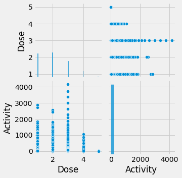

```python
# A pairplot shows pairwise relationships in a dataset.
# The pailot function creates a grid of axes each variable in the data is shared accross the
# y-axis in a single column and x-axis in a single row
sns.pairplot(data)
plt.show()
```

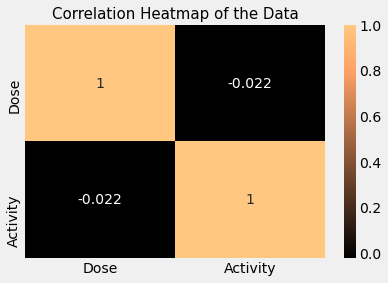

```python
# check the correlation heat map of the data
# correlation helps to check whether the data are stongly related or not.
# for plotting the correlation, we will be using the sns.heatmap function and data.corr function
# annot = True means we want the value of correlation in the box
# cmap = colour map
sns.heatmap(data.corr(), annot = True, cmap = 'copper')
plt.title('Correlation Heatmap of the Data', fontsize = 15)
plt.show()
```

```
Target looks like classification
```

[output not shown]

[output cut: 10 more lines]

[output not shown]

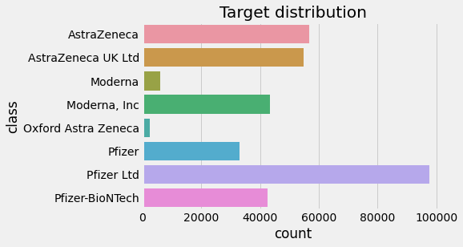

[figure not shown]

```python
# analysis of the data with respect to Vaccine Types using the dabl library (Data Analysis Baseline Library)
# error message to be investigated
# DQ spotted on the names of different vaccine types. Will fix this in Foundry before the full extract
# Pfizer has been the most popular vaccinein the ICS
dabl.plot(data, target_col = 'Vaccine Make')
```

```
Target looks like regression
```

```
[None,
 array([[<AxesSubplot:title={'center':'F=3.77E-02'}, xlabel='Activity', ylabel='Site_Type'>,
         <AxesSubplot:title={'center':'F=2.18E-02'}, xlabel='Activity', ylabel='Site'>,
         <AxesSubplot:title={'center':'F=1.19E-02'}, xlabel='Activity', ylabel='Dose'>,
         <AxesSubplot:title={'center':'F=1.06E-02'}, xlabel='Activity', ylabel='Vaccine Make'>,
         <AxesSubplot:title={'center':'F=5.52E-03'}, xlabel='Activity', ylabel='Corrected Site Type'>]],
       dtype=object)]
```

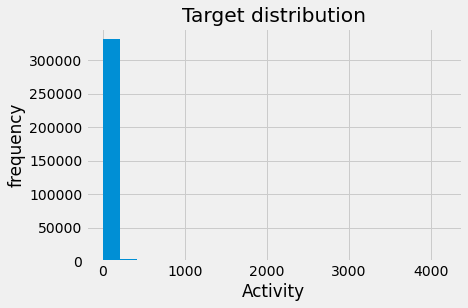

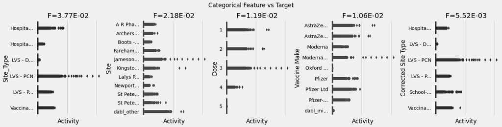

```python
# analysis of the data with respect to Vaccine Types using the dabl library (Data Analysis Baseline Library)
# error message to be investigated
# DQ spotted on the names of different vaccine types. Will fix this in Foundry before the full extract
# Pfizer has been the most popular vaccinein the ICS
dabl.plot(data, target_col = 'Activity')
```

## Descriptive Statistics

```python
# describing the data
data.describe()
```

|  | Dose | Activity |
| --- | --- | --- |
| count | 338067.000000 | 338067.000000 |
| mean | 2.097859 | 12.035348 |
| std | 0.996066 | 75.048939 |
| min | 1.000000 | 0.000000 |
| 25% | 1.000000 | 0.000000 |
| 50% | 2.000000 | 0.000000 |
| 75% | 3.000000 | 0.000000 |
| max | 5.000000 | 4164.000000 |

```python
# describing the categorical data
data.describe(include = 'object')
```

|  | Date | Site_Type | Site | Vaccine Make | Corrected Site Type |
| --- | --- | --- | --- | --- | --- |
| count | 338067 | 338067 | 338067 | 336447 | 338067 |
| unique | 503 | 6 | 92 | 8 | 6 |
| top | 25/10/2021 | LVS - PCN | Kingston Crescent Surgery | Pfizer Ltd | LVS - PCN |
| freq | 811 | 212227 | 8287 | 97503 | 212227 |

```python
# checking if there is any NULL data
data.isnull().any().any()
```

```
True
```

## Data Visualization

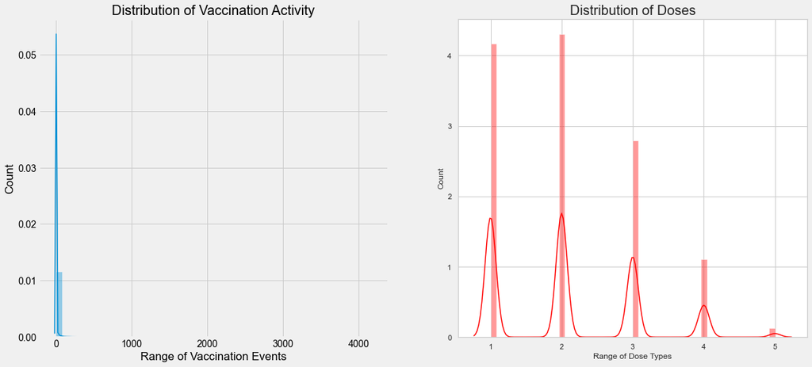

```python
import warnings
warnings.filterwarnings('ignore')

plt.rcParams['figure.figsize'] = (18, 8)

plt.subplot(1, 2, 1)
sns.set(style = 'whitegrid')
sns.distplot(data['Activity'])
plt.title('Distribution of Vaccination Activity', fontsize = 20)
plt.xlabel('Range of Vaccination Events')
plt.ylabel('Count')


plt.subplot(1, 2, 2)
sns.set(style = 'whitegrid')
sns.distplot(data['Dose'], color = 'red')
plt.title('Distribution of Doses', fontsize = 20)
plt.xlabel('Range of Dose Types')
plt.ylabel('Count')
plt.show()
```

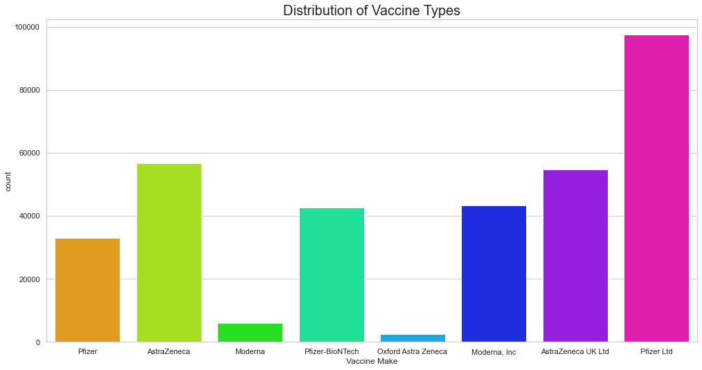

```python
plt.rcParams['figure.figsize'] = (15, 8)
sns.countplot(data['Vaccine Make'], palette = 'hsv')
plt.title('Distribution of Vaccine Types', fontsize = 20)
plt.show()
```

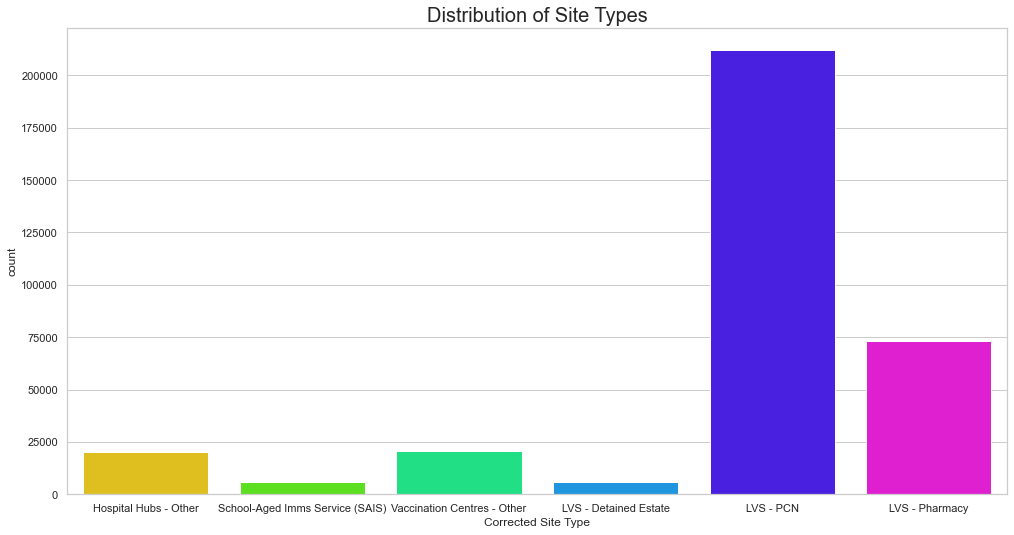

```python
plt.rcParams['figure.figsize'] = (15, 8)
sns.countplot(data['Corrected Site Type'], palette = 'hsv')
plt.title('Distribution of Site Types', fontsize = 20)
plt.show()
```

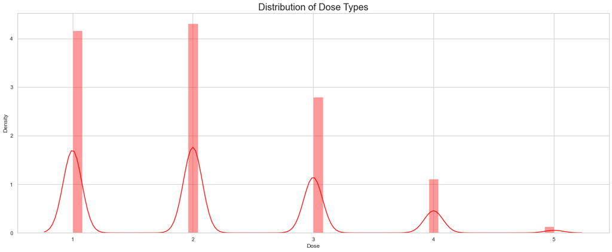

```python
# lets check the ditribution of Doses
plt.rcParams['figure.figsize'] = (20, 8)
sns.distplot(data['Dose'], color = 'red')
plt.title('Distribution of Dose Types', fontsize = 20)
plt.show()
```

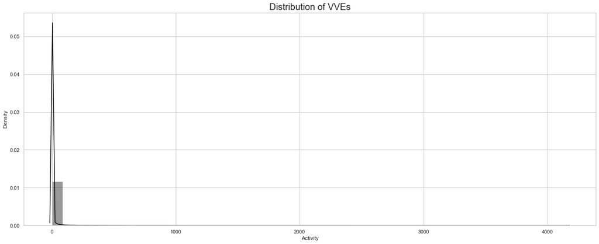

```python
# lets check the distribution of Activity
plt.rcParams['figure.figsize'] = (20, 8)
sns.distplot(data['Activity'], color = 'black')
plt.title('Distribution of VVEs', fontsize = 20)
plt.show()
```

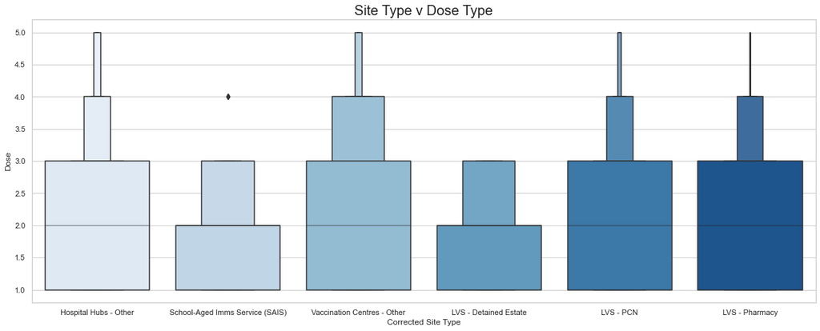

```python
#  Site Type v Dose type
plt.rcParams['figure.figsize'] = (18, 7)
sns.boxenplot(data['Corrected Site Type'], data['Dose'], palette = 'Blues')
plt.title('Site Type v Dose Type', fontsize = 20)
plt.show()
```

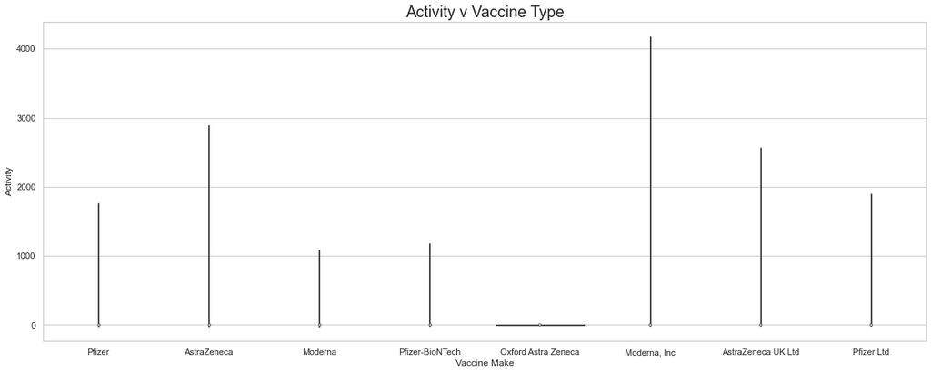

```python
## Vaccine Type v Activity

plt.rcParams['figure.figsize'] = (18, 7)
sns.violinplot(data['Vaccine Make'], data['Activity'], palette = 'rainbow')
plt.title('Activity v Vaccine Type', fontsize = 20)
plt.show()
```

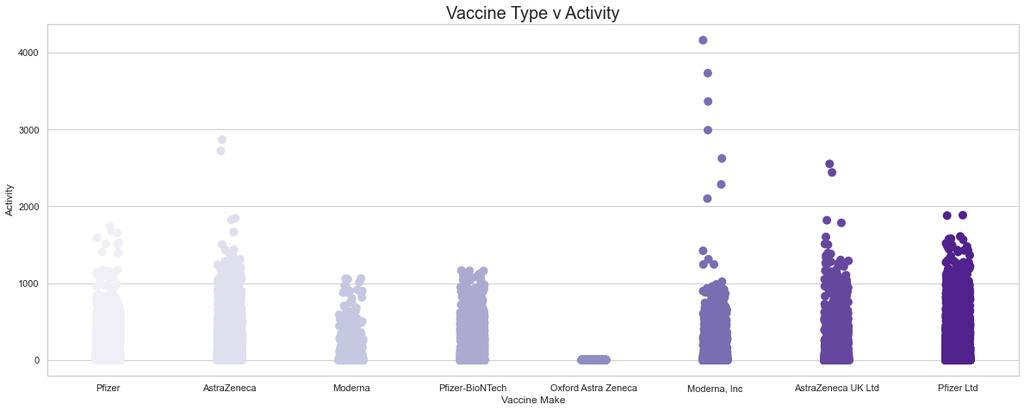

```python
# Vaccine Type v Activity
plt.rcParams['figure.figsize'] = (18, 7)
sns.stripplot(data['Vaccine Make'], data['Activity'], palette = 'Purples', size = 10)
plt.title('Vaccine Type v Activity', fontsize = 20)
plt.show()
```

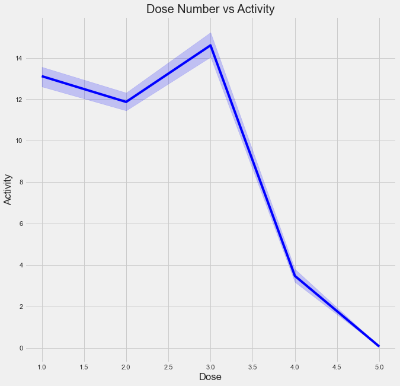

```python
# Dose Number and Activity
x = data['Dose']
y = data['Activity']


sns.lineplot(x, y, color = 'blue')

plt.title('Dose Number vs Activity', fontsize = 20)
plt.show()
```

## Clustering Analysis

```python
# we want to perform clusters of vaccination sites that share similar behaviour

# lets import the warnings library so that we can avoid warnings
import warnings
warnings.filterwarnings('ignore')

# Lets select the Spending score, and Annual Income Columns from the Data
x = data.loc[:, ['Dose', 'Activity']].values

# let's check the shape of x
print(x.shape)
```

```
(338067, 2)
```

```python
# lets also check the data, which we are going to use for the clustering analysis
x_data  = pd.DataFrame(x)
x_data.head()
# where 0->Dose, and 1->Activity
```

|  | 0 | 1 |
| --- | --- | --- |
| 0 | 1 | 0 |
| 1 | 2 | 0 |
| 2 | 3 | 0 |
| 3 | 4 | 0 |
| 4 | 1 | 0 |

## Kmeans Algorithm

**The Elbow Method to find the No. of Optimal Clusters**

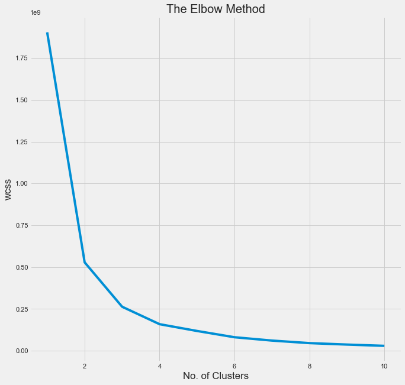

```python
from sklearn.cluster import KMeans

wcss = []
for i in range(1, 11):
    km = KMeans(n_clusters = i, init = 'k-means++', max_iter = 300, n_init = 10, random_state = 0)
    km.fit(x)
    wcss.append(km.inertia_)

plt.plot(range(1, 11), wcss)
plt.title('The Elbow Method', fontsize = 20)
plt.xlabel('No. of Clusters')
plt.ylabel('wcss')
plt.show()
```

**Visualizaing the Clusters**

[figure not shown]

```python
# lets visualize these clusters
plt.style.use('fivethirtyeight')

km = KMeans(n_clusters = 5, init = 'k-means++', max_iter = 300, n_init = 10, random_state = 0)
y_means = km.fit_predict(x)

plt.scatter(x[y_means == 0, 0], x[y_means == 0, 1], s = 100, c = 'pink', label = 'general')
plt.scatter(x[y_means == 1, 0], x[y_means == 1, 1], s = 100, c = 'yellow', label = 'miser')
plt.scatter(x[y_means == 2, 0], x[y_means == 2, 1], s = 100, c = 'cyan', label = 'target')
plt.scatter(x[y_means == 3, 0], x[y_means == 3, 1], s = 100, c = 'magenta', label = 'careful')
plt.scatter(x[y_means == 4, 0], x[y_means == 4, 1], s = 100, c = 'orange', label = 'spendthrift')
plt.scatter(km.cluster_centers_[:,0], km.cluster_centers_[:, 1], s = 50, c = 'blue' , label = 'centeroid')

plt.style.use('fivethirtyeight')
plt.title('K Means Clustering between Site Type & Activity', fontsize = 20)
plt.xlabel('Corrected Site Type')
plt.ylabel('Activity')
plt.legend()
plt.grid()
plt.show()
```

[figure not shown]

```python
from sklearn.cluster import KMeans

wcss = []
for i in range(1, 11):
    kmeans = KMeans(n_clusters = i, init = 'k-means++', max_iter = 300, n_init = 10, random_state = 0)
    kmeans.fit(x)
    wcss.append(kmeans.inertia_)

plt.rcParams['figure.figsize'] = (15, 5)
plt.plot(range(1, 11), wcss)
plt.title('K-Means Clustering(The Elbow Method)', fontsize = 20)
plt.xlabel('Vaccine Make')
plt.ylabel('Count')
plt.grid()
plt.show()
```

[figure not shown]

```python
kmeans = KMeans(n_clusters = 4, init = 'k-means++', max_iter = 300, n_init = 10, random_state = 0)
ymeans = kmeans.fit_predict(x)

plt.rcParams['figure.figsize'] = (10, 10)
plt.title('Cluster of Vacine Types', fontsize = 30)

plt.scatter(x[ymeans == 0, 0], x[ymeans == 0, 1], s = 100, c = 'pink', )
plt.scatter(x[ymeans == 1, 0], x[ymeans == 1, 1], s = 100, c = 'orange',)
plt.scatter(x[ymeans == 2, 0], x[ymeans == 2, 1], s = 100, c = 'lightgreen',)
plt.scatter(x[ymeans == 3, 0], x[ymeans == 3, 1], s = 100, c = 'red')
plt.scatter(kmeans.cluster_centers_[:, 0], kmeans.cluster_centers_[:, 1], s = 50, c = 'black')

plt.style.use('fivethirtyeight')
plt.xlabel('Vaccine Make')
plt.ylabel('Activity')
plt.grid()
plt.show()
```

```python
#NEXT STEPS
#1.ADJUST THE CURRENT QUERIES TO PULL OUT MORE POPULATION INSIGHT FROM NHS FOUNDRY:
    #AGE, GENDER, JCVI COHORTS, MODELLING COHORTS
#2.LIAISE WITH THE NATION MODELLING TEAM TO ALIGN OUR MODELLING FOR THE AUTUMN COMPAIGN
#3.SEE IF WE CAN ADAPT OUR PROJECT FOR ANY IMMUNISATION AND VACCINATION PROJECTS E.G FLU AND SECTION 7

#CONCLUSION
#We did not proceed further due to data extraction restrictions.

#We are now working on a forecasting dashboard to support demand and capacity planning in the NHS SE region.
#Our target completion date is 24 December 2022
```